# Untitled

Mikhail Pankov

09 10 2018

# Векторы - основа R

Для начала постараемся разобраться с векторами и простейшими операциями над ними

### Создание векторов числовых значений

создаем вектор с последовательными значениями и шагом по умолчанию “1”

```r
a<-10:20
a
```

```
##  [1] 10 11 12 13 14 15 16 17 18 19 20
```

также мы можем создать вектор из повторяющихся чисел

```r
b<-rep(666, times=11)
```

Функция “rep” фактически задает команду повторять первое значение в скобках число раз, заданное командой “times”

```r
b
```

```
##  [1] 666 666 666 666 666 666 666 666 666 666 666
```

вектор не для суеверных:) полезная и удобная функция “seq” позволяет создавать последовательность чисел, с учетом разных шагов

```r
seq(10,20)
```

```
##  [1] 10 11 12 13 14 15 16 17 18 19 20
```

также мы можем создавать и простую последовательность,но зачем, если с помощью R можно делать последовательности не с шагом 1

```r
seq(10,20,0.6)
```

```
##  [1] 10.0 10.6 11.2 11.8 12.4 13.0 13.6 14.2 14.8 15.4 16.0 16.6 17.2 17.8
## [15] 18.4 19.0 19.6
```

дальше 20 значения не уйдут, как бы мы этого не хотели

```r
seq(10,20,0.5)
```

```
##  [1] 10.0 10.5 11.0 11.5 12.0 12.5 13.0 13.5 14.0 14.5 15.0 15.5 16.0 16.5
## [15] 17.0 17.5 18.0 18.5 19.0 19.5 20.0
```

можем задать последовательность и по убыванию:)

```r
seq(20,10)
```

```
##  [1] 20 19 18 17 16 15 14 13 12 11 10
```

```r
# или другим способом

20:10
```

```
##  [1] 20 19 18 17 16 15 14 13 12 11 10
```

или вспомним вектор из произвольных чисел

```r
c(1,50,345)
```

```
## [1]   1  50 345
```

# Простейшие операции над векторами

Любой числовой вектор в R это ряд определенных числовых значений, в Excel мы привыкли видеть ряды чисел в виде строк и столбцов, а здесь в виде векторов давайте рассмотрим основные операции над векторами

### ‘Допустим захотелось прибавить к каждому числу вектора значение!!!’

```r
a+156
```

```
##  [1] 166 167 168 169 170 171 172 173 174 175 176
```

Не проблема!:)

### ‘Внезапно появилось желание избавиться от загадочных чисел !!!!’

```r
b-666
```

```
##  [1] 0 0 0 0 0 0 0 0 0 0 0
```

Легко!

И просто изменить ряд:

```r
b <- b-342
b
```

```
##  [1] 324 324 324 324 324 324 324 324 324 324 324
```

# Вспомним основные арифметические действия, они также применимы к векторам

помучаем еще многострадальный вектор!

```r
b*10
```

```
##  [1] 3240 3240 3240 3240 3240 3240 3240 3240 3240 3240 3240
```

```r
b/2
```

```
##  [1] 162 162 162 162 162 162 162 162 162 162 162
```

```r
b^2
```

```
##  [1] 104976 104976 104976 104976 104976 104976 104976 104976 104976 104976
## [11] 104976
```

попробуем найти синус первого вектора!

```r
  sin(a)
```

```
##  [1] -0.5440211 -0.9999902 -0.5365729  0.4201670  0.9906074  0.6502878
##  [7] -0.2879033 -0.9613975 -0.7509872  0.1498772  0.9129453
```

и не забудем корень:)

```r
sqrt(a)
```

```
##  [1] 3.162278 3.316625 3.464102 3.605551 3.741657 3.872983 4.000000
##  [8] 4.123106 4.242641 4.358899 4.472136
```

### попробуем поработать сразу с двумя векторами!

```r
a+b
```

```
##  [1] 334 335 336 337 338 339 340 341 342 343 344
```

попробуем вычесть из вектора b вектор a

```r
b-a
```

```
##  [1] 314 313 312 311 310 309 308 307 306 305 304
```

а если их умножить? Давайте попробуем!

```r
a*b
```

```
##  [1] 3240 3564 3888 4212 4536 4860 5184 5508 5832 6156 6480
```

Важно! Когда мы проводим математические операции вектора по отношению к другому вектору, проводятся математические операции каждого элемента вектора к соответствующему числу другого вектора

Возникают задачи, когда необходимо сравнить значения векторов. Мы также можем это делать достаточно просто!

```r
a=b
```

Сейчас эти векторы равны) хорошо, что избавились от чисел 666:) Проверим, действительно ли это так

```r
a==b
```

```
##  [1] TRUE TRUE TRUE TRUE TRUE TRUE TRUE TRUE TRUE TRUE TRUE
```

А что, если изменить несколько элементов вектора вручную?

```r
a[1]<-666
```

Вновь появилось это загадочное число! Но отличается ли оно от числа другого вектора?

```r
a
```

```
##  [1] 666 324 324 324 324 324 324 324 324 324 324
```

```r
a==b
```

```
##  [1] FALSE  TRUE  TRUE  TRUE  TRUE  TRUE  TRUE  TRUE  TRUE  TRUE  TRUE
```

Сейчас R определил для нас, что первые элементы векторов не равны!

# Нечисловые векторы

### каждый вектор может быть только одного типа, в отличии от привычных таблиц Excel

```r
c(1,'dog', 'pi')
```

```
## [1] "1"   "dog" "pi"
```

все значения вектора были изменены на текстовые, вне зависимости от наших предпочтений:)

давайте рассмотрим и нечисловой тип векторов!

```r
vec<-c('R','is','ineresting')
vec
```

```
## [1] "R"          "is"         "ineresting"
```

Бывает возникает необходимость изменить один из элементов вектора, это можно сделать по аналогии с числовым!

Важно не забывать, что отсчет элементов R начинается с 1ого, а не с 0ого, как во многих языках программирования

```r
vec[3]<-'useful'
vec
```

```
## [1] "R"      "is"     "useful"
```

можно изменить и несколько элементов вектора

```r
vec[c(1,3)]<-c('statistics','great')#  и проверим, так ли это?:)
vec
```

```
## [1] "statistics" "is"         "great"
```

# Векторы с шапкой и некоторые графики

Конечно, мы привыкли выдеть векторы в виде таблиц, да еще и с названиями!

```r
t1<- 2:4
t1
```

```
## [1] 2 3 4
```

### построим первый график!

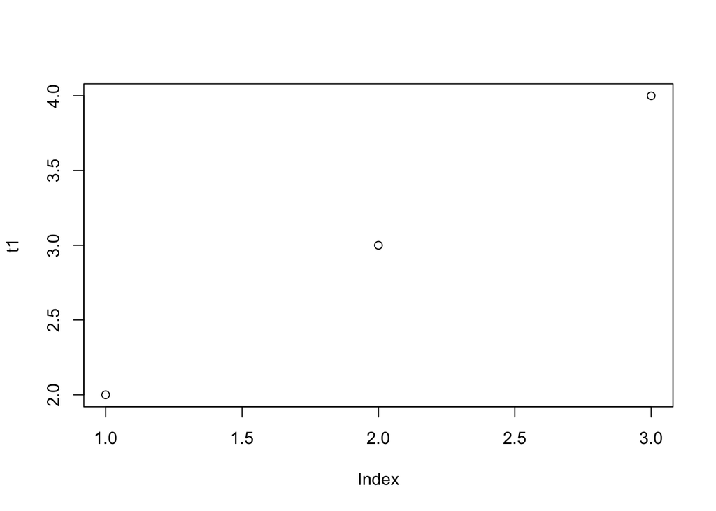

```r
plot(t1)
```

#### а еще построим гистограмму!

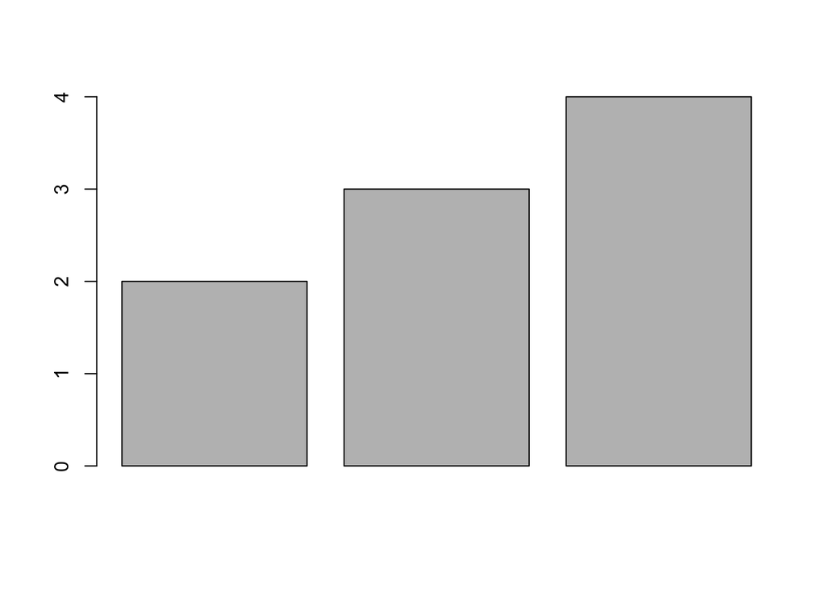

```r
barplot(t1)
```

на гистограмме чего-то не хватает… Точно, мы привыкли видеть названия столбцов:)

Присвоим имена каждому значению вектора! Так будет куда симпатичнее:)

```r
names(t1)<-c('Rus','Eng', 'Ger')
t1
```

```
## Rus Eng Ger
##   2   3   4
```

построим гистограмму еще разок!

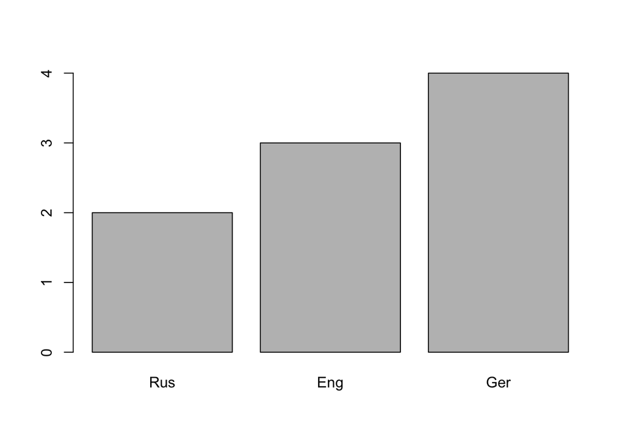

```r
 barplot(t1)
```

### Гистограмма очень похожа на турниры по футболу, но внесем небольшую коррективу для правдоподобия

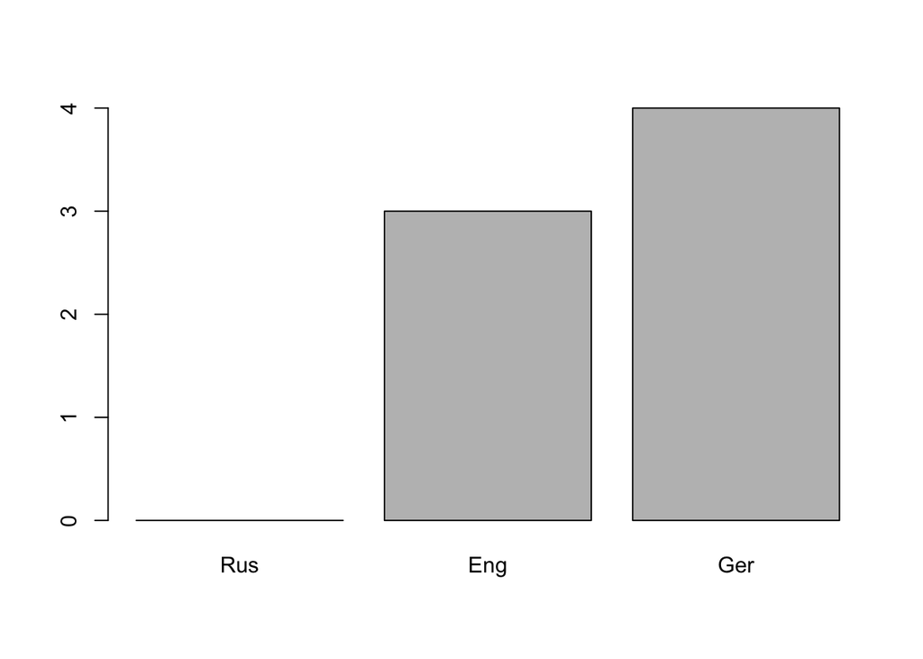

```r
 t1[1]<-0
 barplot(t1)
```

можно строить графики и не по готовым векторам, но это не так удобно

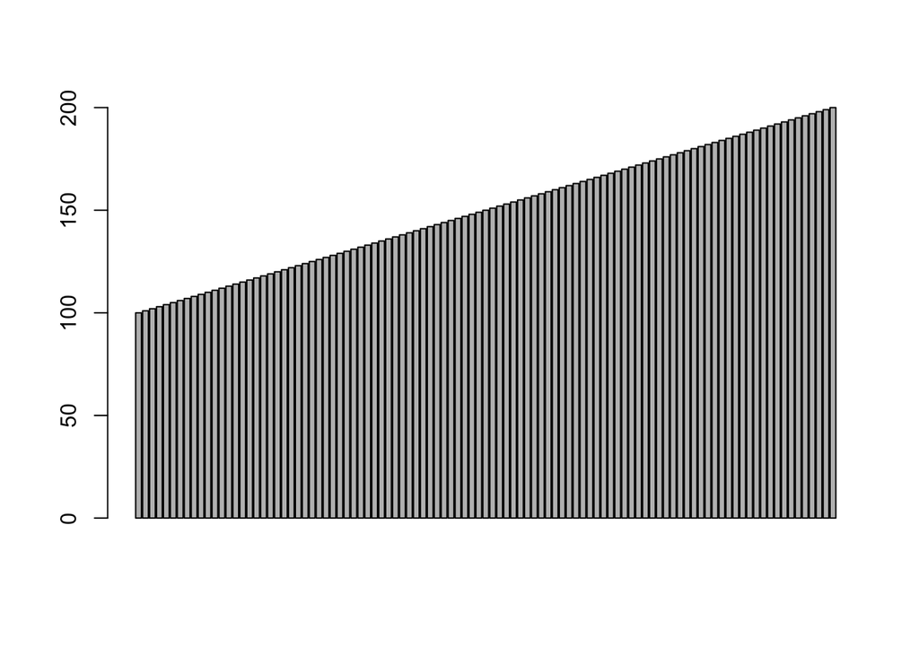

```r
 barplot(100:200)
```

Точечные графики:

```r
  x<-seq(10,20,0.3)
  y<-sin(x)
```

#### Построим x по у!

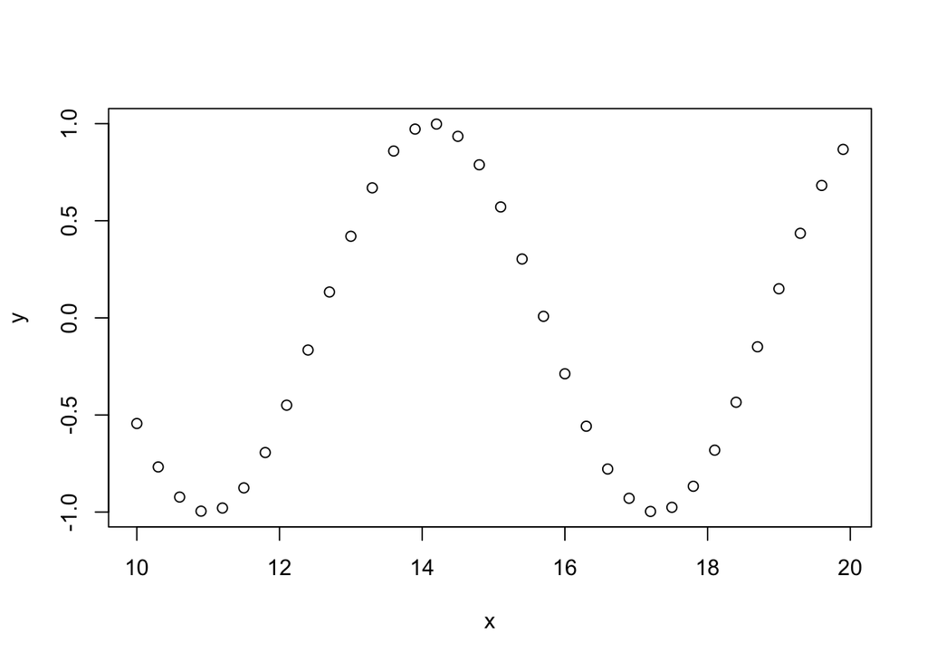

```r
  plot(x,y) # картинка чуть веселей!
```

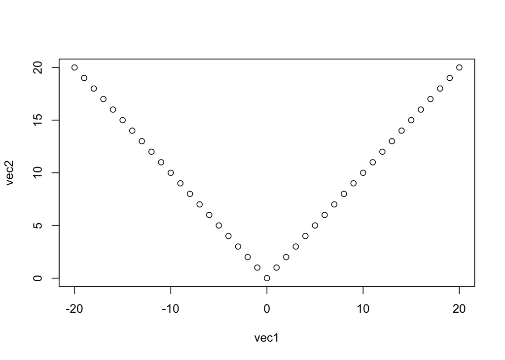

```r
  vec1<- seq(-20,20)
  vec2<-abs(vec1)
  plot(vec1,vec2)
```

такие интересные графики можно строить всего одной командой!!!

## попробуйте построить график где vec1 по оси у, vec2 по х

Дополнительное действие над векторами: (удобно для выборки! и не только:))

Например мы можем создать вектор только с положительными элементами из вектора y

```r
z<-y[y>0]
z
```

```
##  [1] 0.133232041 0.420167037 0.669569762 0.859161815 0.972007501
##  [6] 0.998026653 0.934895056 0.788252067 0.571196870 0.303118357
## [11] 0.007963184 0.149877210 0.435365360 0.681963620 0.867644101
```

## На этом пока все